# Lab 3: COVID-19

Ecosystem Science and Sustainability 330

Author

Cecily Sperber

# Question 1

## Answer: Having easy access to historical and real-time environmnetal data shapes our understanding of climate trends, resource management, and public health by giving the public and scientists/researches the ability to analyze and study trends and patterns as well as create predictions for the future. When this data disappears or becomes inaccessible, it could create challenges for the public and scientists/researchers to understand what is happening in the real world.

# Question 2

```r
my.date <- as.Date("2022-02-01")
my.state <- "Colorado"

colorado_data <- covid_data %>%
    filter(state == my.state) %>%
    arrange(county, date) %>%
    group_by(county) %>%
    mutate(new_cases = cases - lag(cases, default = first(cases)),
           new_deaths = deaths - lag(deaths, default = first(deaths))) %>%
    ungroup()

latest_data <- colorado_data %>%
    filter(date == my.date)

top_cumulative_cases <- latest_data %>%
    slice_max(cases, n = 5) %>%
    select(Date = date, County = county, `Total Cases` = cases) %>%
    flextable() %>%
    add_header_lines("The Top 5 Countires with the Most Cumulative Cases")
top_cumulative_cases
```

| The Top 5 Countires with the Most Cumulative Cases Date | The Top 5 Countires with the Most Cumulative Cases County | The Top 5 Countires with the Most Cumulative Cases Total Cases |
| --- | --- | --- |
| 2022-02-01 | El Paso | 170,673 |
| 2022-02-01 | Denver | 159,022 |
| 2022-02-01 | Arapahoe | 144,255 |
| 2022-02-01 | Adams | 126,768 |
| 2022-02-01 | Jefferson | 113,240 |

```r
top_new_cases <- latest_data %>%
    slice_max(new_cases, n = 5) %>%
    select(Date = date, County = county, `New Cases` = new_cases) %>%
    flextable() %>%
    add_header_lines("The Top 5 Counties with the Most New Cases")
top_new_cases
```

| The Top 5 Counties with the Most New Cases Date | The Top 5 Counties with the Most New Cases County | The Top 5 Counties with the Most New Cases New Cases |
| --- | --- | --- |
| 2022-02-01 | El Paso | 630 |
| 2022-02-01 | Arapahoe | 401 |
| 2022-02-01 | Denver | 389 |
| 2022-02-01 | Adams | 326 |
| 2022-02-01 | Jefferson | 291 |

```r
latest_date <- max(latest_data$date, na.rm = TRUE)
latest_data <- latest_data %>% filter(date == latest_date)

safe_counties <- latest_data %>%
    filter(new_cases < 10) %>%
    select(County = county)

num_safe_counties <- nrow(safe_counties)

safe_counties_table <- safe_counties %>%
    flextable() %>%
    add_header_lines("The Top 5 Counties with Low Case Counts in Colorado")
safe_counties_table
```

[output not shown]

```r
total_new_cases <- sum(latest_data$new_cases, na.rm = TRUE)
total_cumulative_cases <- sum(latest_data$cases, na.rm = TRUE)
```

## Answer: The top counties with the highest total cumulative cases include El Paso, Denver, Arapahoe, Adams, and Jefferson. The top counties with the highest total new cases include El Paso, Arapahoe, Denver, Adams, and Jefferson. The number of safe counties from this data is 34.

# Question 3

```r
population_data <- read_csv("https://www2.census.gov/programs-surveys/popest/datasets/2020-2021/counties/totals/co-est2021-alldata.csv")
covid_data <- read_csv("https://raw.githubusercontent.com/nytimes/covid-19-data/master/us-counties.csv")
population_data_clean <- population_data %>%
  mutate(
    STATE = sprintf("%02d", as.numeric(STATE)),
    COUNTY = sprintf("%03d", as.numeric(COUNTY)),
    FIPS = paste0(STATE, COUNTY)
  ) %>%
  filter(COUNTY != "000") %>%
  select(FIPS, CTYNAME, POPESTIMATE2021, DEATHS2021)

colorado_data <- colorado_data %>%
  mutate(FIPS = as.character(fips))

joined_data <- colorado_data %>%
  left_join(population_data_clean, by = "FIPS")

joined_data <- joined_data %>%
  arrange(FIPS, date) %>%
  group_by(FIPS) %>%
  mutate(
    new_cases = cases - lag(cases, default = first(cases)),
    new_deaths = deaths - lag(deaths, default = first(deaths)),
    per_capita_cumulative_cases = cases / POPESTIMATE2021,
    per_capita_new_cases = new_cases / POPESTIMATE2021,
    per_capita_new_deaths = new_deaths / POPESTIMATE2021
  ) %>%
  ungroup()

top_cumulative_cases <- joined_data %>%
  filter(date == "2022-02-01") %>%
  arrange(desc(per_capita_cumulative_cases)) %>%
  select(County = CTYNAME, Cases = per_capita_cumulative_cases) %>%
  head(5)

top_new_cases <- joined_data %>%
  filter(date == "2022-02-01") %>%
  arrange(desc(per_capita_new_cases)) %>%
  select(County = CTYNAME, Cases = per_capita_new_cases) %>%
  head(5)

flextable(top_cumulative_cases) %>%
  add_header_lines("The Top 5 Counties by Cumulative Cases Per Capita")
```

| The Top 5 Counties by Cumulative Cases Per Capita County | The Top 5 Counties by Cumulative Cases Per Capita Cases |
| --- | --- |
| Crowley County | 0.4881903 |
| Bent County | 0.3818371 |
| Pitkin County | 0.3427484 |
| Lincoln County | 0.3294655 |
| Summit County | 0.3004105 |

```r
flextable(top_new_cases) %>%
  add_header_lines("The Top 5 Counties by New Cases Per Capita")
```

| The Top 5 Counties by New Cases Per Capita County | The Top 5 Counties by New Cases Per Capita Cases |
| --- | --- |
| Crowley County | 0.009314704 |
| Sedgwick County | 0.003852740 |
| Bent County | 0.003820108 |
| Washington County | 0.002880066 |
| Las Animas County | 0.002596870 |

# Question 4

```r
last_14_days <- joined_data %>%
  filter(date >= max(date) - 14)

county_summary <- last_14_days %>%
  group_by(CTYNAME) %>%
  summarize(
    total_new_cases = sum(new_cases, na.rm = TRUE),
    population = first(POPESTIMATE2021),
    new_cases_per_100k = (total_new_cases / population) * 100000
  ) %>%
  ungroup()

top_counties <- county_summary %>%
    slice_max(new_cases_per_100k, n = 5) %>%
    select(County = CTYNAME, Cases = new_cases_per_100k)

top_counties_table <- flextable(top_counties) %>%
    add_header_lines("The Top 5 Counties by New Cases Per 100,000")
top_counties_table
```

| The Top 5 Counties by New Cases Per 100,000 County | The Top 5 Counties by New Cases Per 100,000 Cases |
| --- | --- |
| Mineral County | 865.8009 |
| Boulder County | 814.7647 |
| Larimer County | 559.1215 |
| Denver County | 557.7240 |
| Jefferson County | 470.6849 |

```r
watch_list_count <- sum(county_summary$new_cases_per_100k > 100, na.rm = TRUE)

cat("Number of counties on the watch list: ", watch_list_count)
```

```
Number of counties on the watch list:  56
```

# Question 5

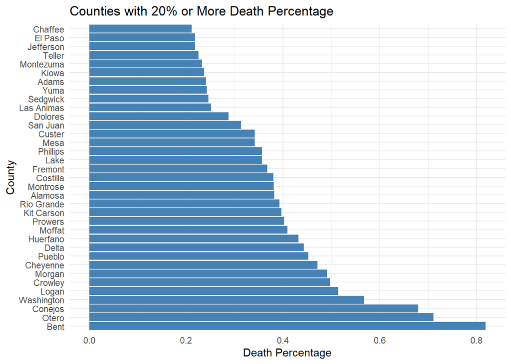

```r
library(ggplot2)
library(dplyr)
library(readr)

covid_deaths <- colorado_data %>%
  filter(date >= as.Date("2021-01-01") & date <= as.Date("2021-12-31") & state == my.state) %>%
  group_by(fips, county) %>%
  summarize(total_covid_deaths = max(deaths, ns.rm = TRUE) -
min(deaths, nr.rm = TRUE), .groups = "drop")

annual_deaths <- population_data_clean %>%
  select(FIPS, POPESTIMATE2021) %>%
  rename(fips = FIPS) %>%
  mutate(annual_deaths = POPESTIMATE2021 * 0.0087)

covid_deaths <- covid_deaths %>%
  mutate(fips = toupper(fips))

death_ratio <- covid_deaths %>%
  left_join(annual_deaths, by = "fips") %>%
  mutate(death_ratio = total_covid_deaths / annual_deaths) %>%
  filter(death_ratio >= 0.2)

death_ratio$county <- factor(death_ratio$county, levels = death_ratio$county[order(death_ratio$death_ratio, decreasing = TRUE)])

ggplot(death_ratio, aes(x = county, y = death_ratio)) +
  geom_bar(stat = "identity", fill = "steelblue") +
  coord_flip() +
  labs(
    title = "Counties with 20% or More Death Percentage",
    x = "County",
    y = "Death Percentage"
  ) +
  theme_minimal()
```

# Question 6

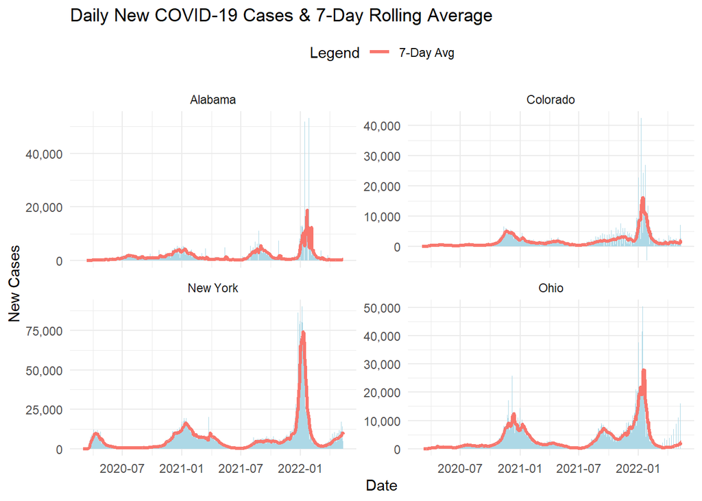

```r
library(ggplot2)
library(dplyr)
library(readr)
library(zoo)

census_data <- read_csv("https://www2.census.gov/programs-surveys/popest/datasets/2020-2021/counties/totals/co-est2021-alldata.csv")
state_population <- census_data %>%
  group_by(STNAME) %>%
  summarize(STATE_POPULATION = sum(POPESTIMATE2021, na.rm = TRUE)) %>%
  filter(STNAME %in% c("New York", "Colorado", "Alabama", "Ohio"))

covid_data <- read_csv("https://raw.githubusercontent.com/nytimes/covid-19-data/master/us-counties.csv")
state_covid_data <- covid_data %>%
  filter(state %in% c("New York", "Colorado", "Alabama", "Ohio")) %>%
  group_by(state, date) %>%
  summarize(total_cases = sum(cases, na.rm = TRUE), .groups = "drop") %>%
  arrange(state, date) %>%
  group_by(state) %>%
  mutate(
    new_cases = total_cases - lag(total_cases),
    new_cases = replace_na(new_cases, 0),
    rolling_avg_cases = zoo::rollmean(new_cases, k = 7, fill = NA, align = "right")
  ) %>%
  ungroup()

state_covid_data <- state_covid_data %>%
  mutate(
    new_cases = as.numeric(new_cases),
    rolling_avg_cases = as.numeric(rolling_avg_cases)
  )

state_covid_data <- state_covid_data %>%
  filter(!is.na(new_cases))

state_covid_data$new_cases[is.na(state_covid_data$new_cases)] <- 0
state_covid_data$rolling_avg_cases[is.na(state_covid_data$rolling_avg_cases)] <- 0

ggplot(state_covid_data, aes(x = date, y = new_cases)) +
  geom_bar(stat = "identity", fill = "lightblue") +
  geom_line(aes(y = rolling_avg_cases, color = "7-Day Avg"), linewidth = 1.2) +
  facet_wrap(~state, scales = "free_y") +
  scale_y_continuous(labels = scales::comma) +
  labs(
    title = "Daily New COVID-19 Cases & 7-Day Rolling Average",
    x = "Date",
    y = "New Cases",
    color = "Legend"
  ) +
  theme_minimal() +
  theme(legend.position = "top")
```

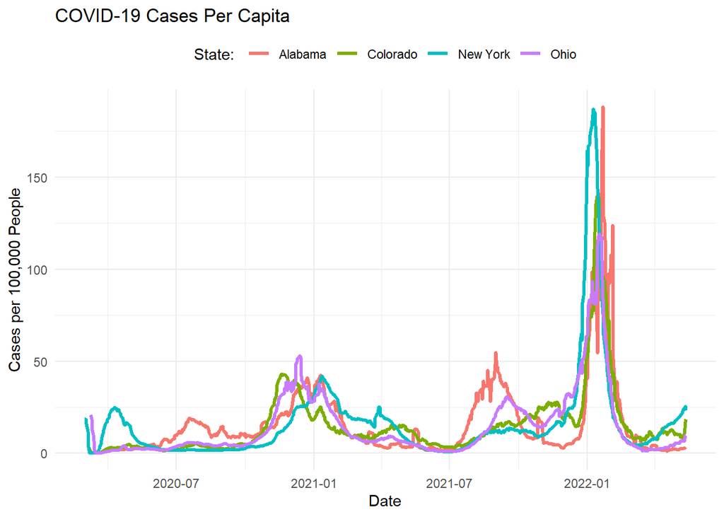

```r
# Plot 2
covid_per_capita <- state_covid_data %>%
  left_join(state_population, by = c("state" = "STNAME")) %>%
  mutate(
    cases_per_capita = (new_cases / STATE_POPULATION) * 100000,
    rolling_avg_per_capita = zoo::rollmean(cases_per_capita, k = 7, fill = NA, align = "right")
  ) %>%
  filter(!is.na(rolling_avg_per_capita))

ggplot(covid_per_capita, aes(x = date, y = rolling_avg_per_capita, color = state)) +
  geom_line(linewidth = 1.2) +
  labs(
    title = "COVID-19 Cases Per Capita",
    x = "Date",
    y = "Cases per 100,000 People",
    color = "State: "
  ) +
  theme_minimal() +
  theme(legend.position = "top")
```

## Answer: Scaling by population gives more context to compare the severity by state. When looking at one state, you have no reference point to analyze it compared to the other states. Alabama and New York look much worse than Colorado and Ohio because they had much more cases per 100,000 people in 2022.

# Question 7

```r
library(tidyverse)
library(lubridate)
library(ggplot2)
library(ggmap)
library(readr)

county_centroids <- read_csv("https://raw.githubusercontent.com/mikejohnson51/csu-ess-330/refs/heads/main/resources/county-centroids.csv")
covid_data <- read_csv("https://raw.githubusercontent.com/nytimes/covid-19-data/master/us-counties.csv")
covid_data <- covid_data %>% mutate(fips = as.character(fips))
county_centroids <- county_centroids %>% mutate(fips = as.character(fips))

missing_fips <- anti_join(covid_data, county_centroids, by = "fips")
print(paste("Missing FIPS count:", nrow(missing_fips)))
```

```
[1] "Missing FIPS count: 29559"
```

```r
covid_with_location <- covid_data %>%
  left_join(county_centroids, by = "fips")

covid_with_location <- covid_with_location %>%
  filter(!is.na(LON) & !is.na(LAT))

summary(covid_with_location$cases)
```

```
   Min. 1st Qu.  Median    Mean 3rd Qu.    Max.
      1     390    1790    9807    5907 2908425
```

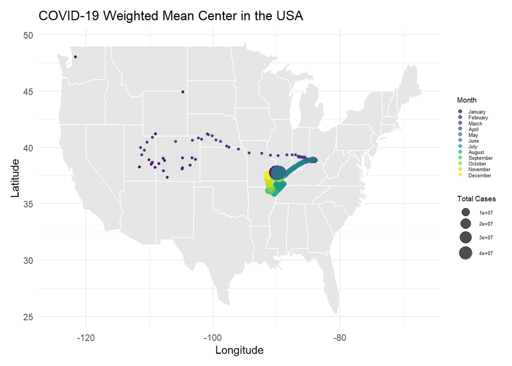

```r
case_threshold <- quantile(covid_with_location$cases, 0.99, na.rm = TRUE)
covid_with_location <- covid_with_location %>%
  filter(cases <= case_threshold)

covid_with_location <- covid_with_location %>%
  mutate(date = as.Date(date))

weighted_mean_center <- covid_with_location %>%
  group_by(date) %>%
  summarize(
    total_cases = sum(cases, na.rm = TRUE),
    WMC_LON = sum(LON * cases, na.rm = TRUE) / sum(cases, na.rm = TRUE),
    WMC_LAT = sum(LAT * cases, na.rm = TRUE) / sum(cases, na.rm = TRUE),
    month = month(date)
  ) %>%
  filter(!is.na(WMC_LON) & !is.na(WMC_LAT))
weighted_mean_center <- weighted_mean_center %>%
  mutate(month = factor(month, levels = 1:12, labels = month.name))

filtered_wmc <- weighted_mean_center %>%
  filter(WMC_LON >= -130 & WMC_LON <= -60 &
         WMC_LAT >= 20 & WMC_LAT <= 55)

ggplot() +
  borders("state", fill = "gray90", colour = "white") +
  geom_point(data = filtered_wmc,
             aes(x = WMC_LON, y = WMC_LAT, color = month, size = total_cases),
             alpha = 0.7) +
  scale_color_viridis_d() +
  theme_minimal() +
  labs(
    title = "COVID-19 Weighted Mean Center in the USA",
    x = "Longitude",
    y = "Latitude",
    color = "Month",
    size = "Total Cases"
  ) +
  theme(
    legend.position = "right",
    legend.title = element_text(size = 7),
    legend.text = element_text(size = 5),
    legend.key.size = unit(0.2, "cm"),
    legend.spacing.y = unit(0.2, "cm"),
    plot.margin = margin(10, 10, 10, 10)
  )
```

## Answer: Most of the COVID-19 weighted mean center in the USA occurred between the states Missouri and Arkansas during the later months of the year. There is some small outbreaks around the state of Colorado as well during Janurary through March. The reason there was such a large outbreak in the Missouri and Arkansas was because of a new highly contagious COVID-19 variant (Delta) affecting the nation.

# Question 8

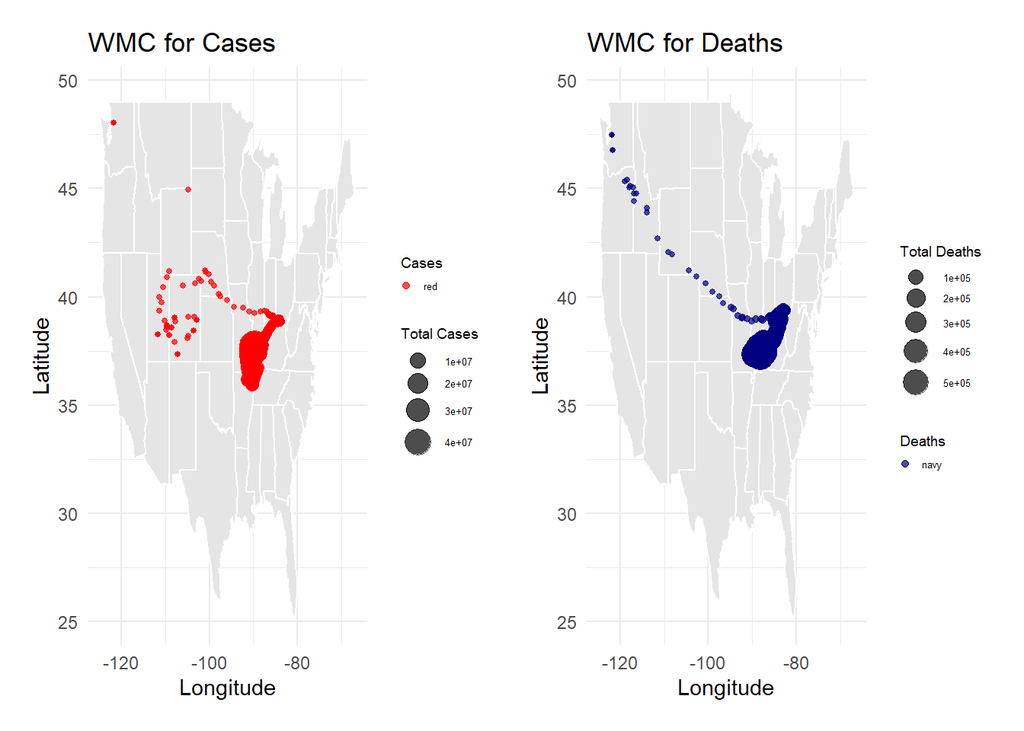

```r
library(tidyverse)
library(lubridate)
library(ggplot2)
library(ggmap)
library(patchwork)

weighted_mean_center_cases <- covid_with_location %>%
  group_by(date) %>%
  summarize(
    total_cases = sum(cases, na.rm = TRUE),
    WMC_LON_cases = sum(LON * cases, na.rm = TRUE) / sum(cases, na.rm = TRUE),
    WMC_LAT_cases = sum(LAT * cases, na.rm = TRUE) / sum(cases, na.rm = TRUE)
  )

weighted_mean_center_deaths <- covid_with_location %>%
  group_by(date) %>%
  summarize(
    total_deaths = sum(deaths, na.rm = TRUE),
    WMC_LON_deaths = sum(LON * deaths, na.rm = TRUE) / sum(deaths, na.rm = TRUE),
    WMC_LAT_deaths = sum(LAT * deaths, na.rm = TRUE) / sum(deaths, na.rm = TRUE)
  )

weighted_mean_center_cases <- weighted_mean_center_cases %>%
  filter(!is.na(WMC_LON_cases) & !is.na(WMC_LAT_cases))

weighted_mean_center_deaths <- weighted_mean_center_deaths %>%
  filter(!is.na(WMC_LON_deaths) & !is.na(WMC_LAT_deaths))

weighted_mean_center_cases <- weighted_mean_center_cases %>%
  filter(WMC_LON_cases >= -180 & WMC_LON_cases <= 180,
         WMC_LAT_cases >= -90 & WMC_LAT_cases <= 90)

weighted_mean_center_deaths <- weighted_mean_center_deaths %>%
  filter(WMC_LON_deaths >= -180 & WMC_LON_deaths <= 180,
         WMC_LAT_deaths >= -90 & WMC_LAT_deaths <= 90)

plot_cases <- ggplot() +
  borders("state", fill = "gray90", colour = "white") +
  geom_point(data = weighted_mean_center_cases,
             aes(x = WMC_LON_cases, y = WMC_LAT_cases, color = "red", size = total_cases),
             alpha = 0.7) +
  scale_color_manual(values = "red") +
  theme_minimal() +
  labs(
    title = "WMC for Cases",
    x = "Longitude",
    y = "Latitude",
    color = "Cases",
    size = "Total Cases"
  ) +
  theme(
    legend.position = "right",
    legend.title = element_text(size = 7),
    legend.text = element_text(size = 5),
    legend.key.size = unit(0.2, "cm"),
    legend.spacing.y = unit(0.2, "cm"),
    plot.margin = margin(10, 10, 10, 10)
  )

plot_deaths <- ggplot() +
  borders("state", fill = "gray90", colour = "white") +
  geom_point(data = weighted_mean_center_deaths,
             aes(x = WMC_LON_deaths, y = WMC_LAT_deaths, color = "navy", size = total_deaths),
             alpha = 0.7) +
  scale_color_manual(values = "navy") +
  theme_minimal() +
  labs(
    title = "WMC for Deaths",
    x = "Longitude",
    y = "Latitude",
    color = "Deaths",
    size = "Total Deaths"
  ) +
  theme(
    legend.position = "right",
    legend.title = element_text(size = 7),
    legend.text = element_text(size = 5),
    legend.key.size = unit(0.2, "cm"),
    legend.spacing.y = unit(0.2, "cm"),
    plot.margin = margin(10, 10, 10, 10)
  )

combined_plot <- plot_cases + plot_deaths + plot_layout(ncol = 2)
print(combined_plot)
```

## Answer: The weighted mean center for deaths has a large hotspot around the states Missouri, Kentucky and Indiana. There is also some spread out data from Washington down to the hotspot but is very small and dispersed. The weighted mean center for cases however has a hotspot more around the states Missouri and Arkansas with some small spread out data around the state of Colorado. From this data we can infer there was more COVID-19 impacts on the midwest than the rest of the nation.